# Memo on Rigorous Impact Evaluation Strategies

Author

wzb-ipi

# 1 Overview

There is a growth in the use of Rigorous Impact Evaluation (RIE) to learn about the effects of development interventions.[^1] In this memo, we describe the kinds of strategies that we employ. We emphasize the benefits, but we outline the potential difficulties – including procedural and ethical questions – associated with these strategies.

The key benefits are:

- **An excellent ability to estimate real impacts of programs.** Development professionals work hard to bring about positive effects. They and their funders want to know when their efforts are successful.
- **Generation of knowledge about the relative effectiveness of different approaches.**
- **Generation of systematic data to inform programming.**

However, the approach cannot be used everywhere since it:

- **Requires early integration of evaluation considerations into program design.**
- **Requires sufficient numbers of “units”** (depending on the program, units might be individual beneficiaries or entire communities) to allow for the generation of precise estimates.
- **Is sometimes more costly than evaluations** that depend on short post-implementation visits by consultants (note that we usually provide our support pro bono, but systematic data collection before and after the intervention can be costly).

# 2 Evaluation Questions and Hypotheses

Each of our studies is structured around the examination of a set of hypotheses. These hypotheses are typically generated together with practitioners and identify expected (or possible) effects of interventions.

Developing and stating clear and testable hypotheses is hard because it often requires specifying more concrete claims than are required in grant applications and other writing about projects. In particular, specifying claims through hypotheses requires focusing only on measurable outcomes of programming which may not capture all the aspirations that programmers have for their programs.

An example of a hypothesis is:

- **H1**: Gaining private rights to land results in increased investments in agriculture

It can be helpful for design purposes if hypotheses are more specific. An example of a somewhat more specific hypothesis is:

- **H2**: Access to energy efficient stoves reduces wood consumption by at least 30%

Some hypotheses are more “predictive” and some are more “exploratory.” Predictive hypotheses may be used to determine whether an intervention was successful or not in light of some previously identified set of criteria. Evidence for a predictive hypothesis suggests that a program met its objectives. In many cases, however, it is important to examine whether programs have a particular set of effects even if one is not confident that the program will have those effects. For example, a practitioner implementing a program that gives access to microcredit might predict gains in welfare but might also be interested in learning whether the program improves women’s status or political participation. The latter questions could form the basis of exploratory hypotheses; they can be used to learn about program impact but do not provide criteria for determining whether a program was formally “successful” or not.

**When are hypotheses formed?** A key feature of all hypotheses that we examine is that they are generated **before** a program is implemented. The reason for this is that when hypotheses are generated after program development, there is a risk of the introduction of statistical bias. In particular, there may be a tendency to generate hypotheses based upon relationships that appear in the data, even if these relations do not have causal importance.

Agreeing together on a set of hypotheses is the **first step** in the design of an evaluation.

# 3 Approaches to Evaluation

At the heart of any good evaluation is a strategy to answer the question, **“What would have happened in this program area if there had not been a program?”**

Simple “before-after” comparisons are, unfortunately, not enough because even if there are improvements over time in the program areas, it will be difficult to know whether these improvements are due to the project. One might find that since the program began, things in the program communities improved, and thus conclude that the program must be the cause. Further investigation, however, could show that conditions improved in all communities during the time the program was running—program and non-program communities alike. This might be because of something completely unrelated to the program, such as improving economic conditions or a change in government.

In fact, it is also quite possible that a program succeeds but indicators actually worsen in the communities that receive the program because of adverse events unrelated to the program (for example, droughts, population movements, and so on). In such cases, a good design should be able to show that even though things became worse, the situation in the program community is still substantially better than it would have been in the absence of the program. For this reason too, simply talking to beneficiaries of a project is not enough since, although the perspectives of beneficiaries are fundamentally important, gathering these perspectives does not provide sufficient information to know how beneficiaries fared relative to non-beneficiaries.

In our analyses, we call the units which receive the project the **“treatment” units** (they can be sites, communities, villages, individuals, etc.), and the units that do not, the **“control” units**. These can also be referred to perhaps more simply as the “project” units and “comparison” units. The core of the evaluation will then consist in comparing the outcomes of the project units with those of the comparison units.

The key design challenge for a strong evaluation is to identify a good **“control” group** for each program area. A good control group should be in all ways identical to the treatment group except for the fact that it did not receive treatment. This is called **balance**.

Balance is very hard to achieve. For example, in some cases, project designers choose particular sites as treatment sites precisely because of some positive features, such as their investment possibilities. In such cases, unless the control sites are just as good in terms of investment prospects, the principle of balance is violated, and the evaluation will not be able to tell whether differences in outcomes are really due to the program or whether they are instead due to fundamental differences in investment climates.

Factors like “investment climate” in this example are called **“confounding factors.”** Confounding factors are characteristics that are correlated with both the likelihood that a given subject will receive the treatment and the likelihood that the treatment will succeed. Confounding factors complicate the researcher’s ability to assess the effectiveness of the treatment because they make it difficult to tell if differences between treated and control group outcomes are due to the treatment or to the confounding factor.

One might address the problem of balance by trying to think of all of the confounding factors and compare only those treated and control cases that are very similar on these factors. In that way, one could plausibly claim that the only major difference between the treated and control cases is the fact that one received the treatment and the other did not. This technique is called **“matching.”** While the matching approach is far superior to one that does not factor in the systematic differences between treated and control cases, the approach suffers from important shortcomings.

First, the analyst must think of all of the confounding factors that may affect the outcome of the treatment, a daunting task and one that is constrained by the imagination of the researcher. Second, the analyst must obtain measures of all of these confounding factors. Unfortunately, in many cases these factors may be unobserved so that measures are unobtainable.

Despite these challenges, two approaches hold particular promise for identifying causal effects without bias: the **randomized evaluation approach** and the **regression discontinuity approach**.

## 3.1 Randomized Impact Evaluations

An excellent approach way (from a learning perspective) to identify a good control group is through the method of **“randomized intervention.”** Essentially, the process of randomized intervention works as follows: if there are 100 people that will receive some treatment and 200 people who are eligible to receive the treatment, then 100 people are chosen randomly from the group of 200 eligible people and assigned the treatment. All 200 people, however, are tracked. The fact that the 100 are chosen randomly means that (in expectation) there is no systematic difference between those that did and those that did not receive the treatment—the only systematic difference lies in the treatment itself. Since our treated cases are drawn randomly from the whole sample, treated and control cases are just as likely to bear any particular confounding characteristic, and if the sample size and number of treated cases is large enough, the treated and control cases will on average be very similar. The beauty of randomization (combined with a large enough sample) is that it renders our treated and control cases similar on average even on factors that are unobserved and even on factors that the researcher does not know are confounding but in fact are.

Often when researchers present evidence for the effect of a program, critics ask, “but did you ‘control’ for this or that?” or “but how do you take account of all of the unique features of each unit?” The great advantage of a randomized evaluation approach is that one has always controlled for everything in the sense that there are no third factors that are systematically related to treatment. As a result, the findings do not depend on the idiosyncrasies of the treated units but on what they have in common—exposure to the treatment.

The randomized evaluation approach is common in the study of health and technology, but is rarer in the examination of social interventions in developing countries. Yet it is an approach to which researchers and development organizations are increasingly turning in order to find reliable estimates of program impact.

The basic idea of the approach is simple. However, the approach requires more coordination between the evaluation team and implementing team than is typically the case.

## 3.2 The Regression Discontinuity Approach

In some cases (for practical or ethical reasons), randomization is simply not possible and second-best strategies need to be found to identify good control units. One useful approach is the **regression discontinuity approach.**

This works as follows. Say that some program is going to be made available to a set of individuals. Ex ante, we identify a pool of **“potential beneficiaries”** that is twice as large as the targeted beneficiary number.

These potential beneficiaries are all ranked on a set of relevant criteria, such as prior education levels, employment status, and so on. These criteria can be quantitative, but they can also include assessments from interviews or other qualitative information. These individual criteria are then aggregated into a single score and a threshold is identified. Candidates scoring above this threshold are admitted to the program, while those below are not. **“Project”** and **“comparison”** groups are then identified by selecting applicants that are close to this threshold on either side.

Using this method, we can be sure that treated and control units are similar, especially around the threshold. Moreover, we have a direct measure of the main feature on which they differ (their score on the selection criteria). This information provides the key to estimating a program effect from comparing outcomes between these two groups. The advantage of this approach is that all that is needed is that the implementing agency uses a clear set of criteria (which can be turned into a score) upon which they make treatment assignment decisions. The disadvantage is that reliable estimates of impact can only be made for units right around the threshold.

# 4 What are the steps of an evaluation process?

A typical evaluation process has the following elements:

1. **Design.** We develop hypotheses, research questions, and measures together with implementing partners.
2. **Funding.** If funding is not already in place, funding for the evaluation is sought.
3. **Protocol development.** Terms of collaboration between researchers and program implementers are developed and the design is sent out for peer review and consultation with an appropriate ethics review board.
4. **Unit Identification.** Identify the population of potential treatment units; typically this number will be about twice as large as the ultimate beneficiary population.
5. **Baseline Measurement.** Once all potential beneficiaries are identified, collect a set of baseline measures for all units. Note that these baseline measures should ideally be collected after all potential units are identified, but before actual treatment and control units are determined.
6. **Lottery / Selection.** The project sites are then randomly chosen in the randomized trial design (or the cut-off is identified in the regression discontinuity design)
7. **Project implementation**
8. **Follow up Measurement.** Finally, after the completion of the project, a second set of measures is collected in both project and comparison communities. These can include quantitative, qualitative, and behavioral components.
9. **Analysis.** The core analysis consists of comparing the conditions in the sites where the program was run to conditions in the sites where it was not run. Depending on the exact design and type of data collection, the method can also let us see what elements of the program are most effective.

# 5 What is the motivation of the research team?

The fundamental motivation of the research team is to find answers to major development challenges. We believe that with a better understanding of what sorts of interventions work where, we can gain deeper knowledge into fundamental social processes and also contribute to a knowledge base that can help inform future development strategies. Our motivation here is as researchers, not as consultants.

This motivation has implications for how and where we work:

- **Project Selection:** We focus on projects that have a strong potential for generating knowledge that has implications for other projects and processes around the world.
- **Remuneration:** In order to maintain independence, we typically undertake work of this form on a pro bono basis. That is, we would not seek remuneration from implementing agencies for taking part in this work.
- **Publication Rights:** While we will not seek remuneration, we will want to retain unrestricted rights to analyze and publish from data generated from the research. We will in all cases share all writing with the implementing partner for commentary and feedback before publication, but to maintain the integrity of research, academic output is not subject to approval by partner organizations. These are elements that we would put into a memorandum of understanding.
- **Project Costs:** We do not finance project or research costs (e.g. travel, data collection, dissemination of results) beyond our time contribution. In some cases, evaluation budgets are written into project grants; in others, independent funding needs to be sought.

# 6 Where might we run into problems?

From working on related interventions elsewhere, we think we can see ahead of time where difficulties are most likely to arise. We highlight these here:

- **Statistical Power:** For these approaches to work, one needs a fairly substantial number of units (individuals or communities, depending on the project). This gives what we call statistical “power.” For an intervention that is expected to have strong effects, one needs on the order of about 100 treated and 100 control units. For programs where effects are likely to be weaker one might need more like 1000 or 2000 units. Numbers fundamentally depend on the likely size of effects. These approaches cannot be used with numbers in the order of 10 or 20 units. Also, power depends to some extent on how close units are to each other; if units are too close and there is a risk that “control” units learn from “treated” units, then there is a risk of underestimating the effectiveness of a program.
- **Timing:** Time is needed between the identification of all potential sites and the selection process (whether it be through lotteries or through identification of selection criteria and a cutoff point) in order to undertake a baseline survey (where relevant). Depending on the scale, this could take perhaps 1 to 3 months. This pause can sometimes be inconsistent with the natural schedule of a project.
- **Randomization:** The strongest evaluation strategy requires randomization of program assignment at least for some (though perhaps not all) units. Some people do not like the idea of using randomization as a part of development processes. Indeed, in some cases, randomization is not appropriate, but there are quite strong ethical reasons for why in some cases randomization might be an especially fair approach. Moreover, there are different ways of doing randomization; in some cases, simply varying the timing of which communities are worked with can be sufficient. If partner organizations are uncomfortable with the idea of randomization, then this approach will not work.
- **Mistrust:** Sometimes there can be mistrust between practitioners and researchers, especially if practitioners think researchers are trying to make judgments on how well practitioners are doing their job or if practitioners feel that researchers are only interested in abstract questions that are not relevant for the organization. To avoid this, it is best if there is clear understanding of why researchers are willing to get involved, and also to make sure that the questions being addressed really are of joint interest.

All of these difficulties are things that can and have been overcome in many projects. We raise them early to anticipate potential problems and how they may be addressed.

# 7 Practical Implications for Programming

A robust evaluation strategy involves a substantial commitment of both time and money, and requires that the evaluation team works closely with the project team throughout the lifespan of the project. Unlike many evaluations that are put together after programs are completed, a randomized or regression discontinuity evaluation is built into a program from the very start. This has implications in a number of areas:

- **Criteria for selecting units:** Before any sites are selected, criteria need to be established upon which all units will be selected. We can help establish these criteria, but will of course look to you to lead this process.
- **Number of sites to be identified:** Based on the criteria, typically twice as many sites need to be identified as will eventually be selected.
- **Lotteries:** In the case of randomized interventions, once all potential sites are identified, lotteries are held to determine which sites will be project sites. All sites must have an equal chance of receiving the project. This is crucial! If units are selected in advance of the lottery, then they cannot form a part of the evaluation. (If there are some areas that are clear priority sites, these should naturally be removed from the public lotteries; in this case, however, these sites cannot be a part of the impact evaluation). This lottery approach is a transparent and equitable approach to identifying sites, as long as all sites in the lottery pool are approximately in equal need of the project. In some contexts, political and organization pressures may be such that the outcomes of lotteries are ignored and politically “favored” sites are selected. If this occurs, estimates from the evaluation will not be valid. If the lotteries are to be held in public, then we will work with you to develop clear protocols for running these lotteries.
- **Data collection:** We will need to collect data on all of the treatment and control communities. If we were to collect data from only some of the communities, the power of our findings would be significantly diminished. We would not have enough statistical power in our data to draw meaningful conclusions. There are two implications of this part of the process. First, we will look to you to help develop measures that are appropriate to the local context. Second, we will need to coordinate schedules to ensure that the baseline data collection happens after the determination of the pool of sites but before the actual selection.

# 8 A Few Questions & Answers

Here are answers to a few common questions on impact evaluation. We welcome any more you have!

## 8.1 Q: Why is the randomization process so important?

**A:** The random selection is so important because we want the program and comparison communities to be as similar as possible at the outset. That way, if we see that by the end of the program, conditions have improved in the program communities, we can conclude that the cause of the improvement must have been the program, since the program and comparison communities were in all other ways the same.

We recognize that randomly choosing treatment communities from a larger population makes the implementation process a little more complicated than it would be otherwise. However, it is very important to be able to have comparison communities. Sometimes you will see evaluations where the evaluator has only tracked progress in the program communities, ignoring all other areas. The evaluator might see that since the program began, things in the program communities improved, and thus conclude that the program must have helped. Further investigation, however, could show that conditions improved in all communities during the time the program was running—program and non-program communities alike. This might be because of something completely unrelated to the program, like improving economic conditions or a change in government.

More commonly, however, people track outcomes in communities that they want to use as comparison areas but which were not part of a lottery process. This can cause important problems for assessing impact since there are typically some systematic features that distinguish the project communities from the comparison communities. For example, it could be that one area was selected and another not because it is worse off, or more prone to conflict and so on. But then, if things look no better in the first community than in the second at the end of the project, we could be wrong to infer that the program had no effect; it is possible that it did have an effect precisely by making the worse-off community as well off as the better-off community.

## 8.2 Q: Is this evaluation strategy ethical? Isn’t it unfair to choose some communities and not others? Will choosing some communities lessen the chances for the comparison communities to one day receive projects of their own?

**A:** Ethics is very important to us. All development projects are implemented in some places and not in others. The strategy here does nothing to prevent projects happening in any areas or to affect the total number of projects. Rather, the focus is on identifying specific areas where the project will not take place in order to learn about the areas where it does take place. A couple of principles are important, however.

1. Care should be taken to ensure that the set of areas that are identified for the lottery are all needy areas; areas that are not needy should not be included just to make up the numbers.
2. If it turns out that there are some areas that are clearly needier than all the rest, it may be inappropriate to include these in a lottery. In this case, the program should be implemented in these areas and the lottery should be held over all the other, equally needy areas. In this case, the neediest areas will not be integrated into the evaluation.
3. It should be noted that random selection among equally needy areas is often more equitable than other forms of program allocation. If the selection process is by public lottery, community members will know how and why sites were chosen; they will know that they had the same chance as the others and that they were not discriminated against. Finally, being a “comparison” community does not mean that community should in any way be prevented from receiving programming of their own from any other practitioners or from other initiatives.

## 8.3 Q: Has this kind of an evaluation strategy been done before?

**A:** This method of randomization has been used for project evaluation in a host of recent development projects including community-driven development interventions by IRC and DFID in Liberia and Congo, by the World Bank in Indonesia and Sierra Leone, and by the NSP in Afghanistan. It is being very well received by the policy and donor community.

## 8.4 Q: Is this approach consistent with other approaches such as qualitative approaches or participatory rural appraisals?

**A:** Yes. The core to this approach is working out what the appropriate comparisons are in order to work out impact. Actual data collection and analysis can then be done using multiple approaches. We expect that a quantitative approach will play a central role; however, combining this perspective with qualitative and ethnographic research in the study area can often lead to more insightful results.

# 9 Appendix: statistical power

**Power Illustration**

The figure below shows how many units you would need in each group for a simple design to hit 80% power, meaning there is an 80% chance you you find a significant result. The horizontal access shows different possible effect sizes. A standardized effect of .4 is already quite large. Roughly it is like shifting some probability of a good outcome (versus a bad outcome) from 40% to 60%.

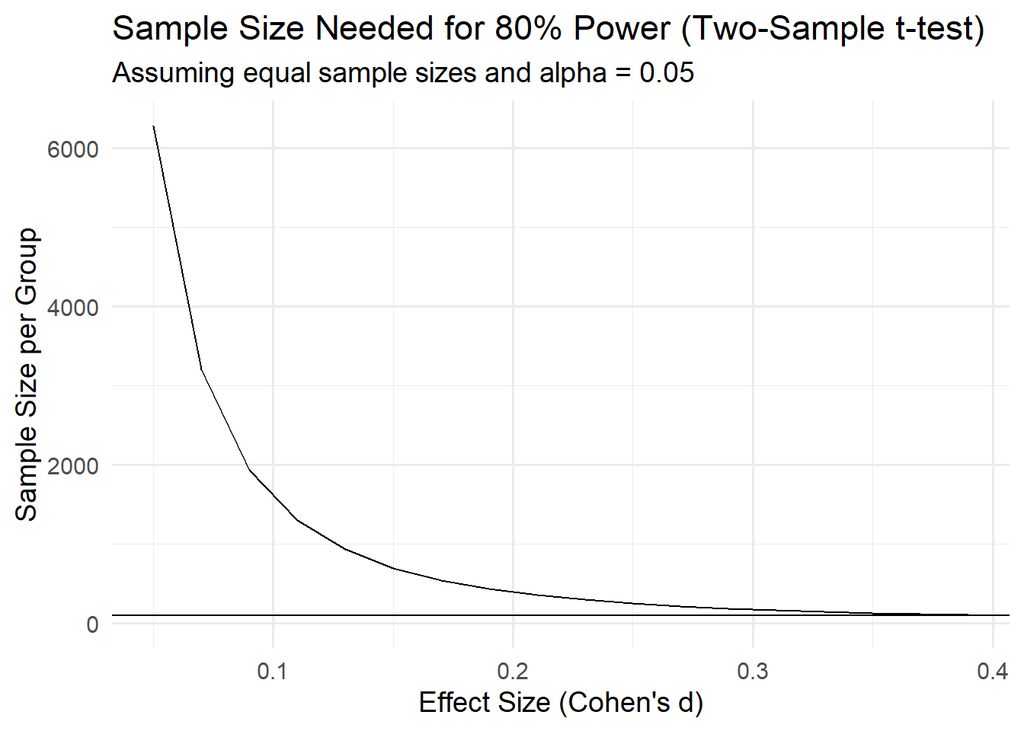

## Footnotes

[^1]: We do not love the term ‘RIE’ as it seems to imply that other strategies are not rigorous. We use it here to be consistent with [common usage](https://rie.deval.org/what-is-rie/what-is-rigorous-impact-evaluation-rie) in German development programming.